# Leave-One-In and Leave-One-Out Analyses

Published

September 10, 2026

# 1 Single-stock comparisons

Each panel overlays one sensitivity model on **Base 1.06: all data**. LOI and LOO are shown separately below, with the same axes across all eight panels. The solid black line is always the base; the dashed coloured line is the model named in the panel.

These are point estimates of spawning biomass for the assessment years, 1970–2026. The model reports biomass in thousand tonnes; values below are divided by 1,000 to show million tonnes.

Only the recent index groups are varied: Chile CPUE, Offshore CPUE, both Peru CPUEs, and Chile Acoustic N. As implemented in `run_loo.R`, “left out” means that the index error is multiplied by 100, strongly reducing its weight. Other indices, catches and composition data retain their base treatment.

## 1.1 LOI — leave one in

The named recent index group retains its base weight; the other recent groups are downweighted.

The LOI runs showed substantial differences in the scale of recent spawning biomass. Retaining North Chile acoustics (Chile Acoustic N; model 3.04) produced the highest 2026 estimate, 24.28 million tonnes, compared with 6.11 million tonnes in the all-data base (297% higher). Retaining both Peru CPUE series (3.03) also produced a much higher estimate, 13.22 million tonnes (116% higher). The Offshore CPUE-only run (3.02) was closer to the base at 7.10 million tonnes (16% higher), whereas the Chile CPUE-only run (3.01) was lower at 4.61 million tonnes (25% lower). These results indicate contrasting signals among the recent index groups, with particularly strong recovery in the North Chile acoustic-only run.

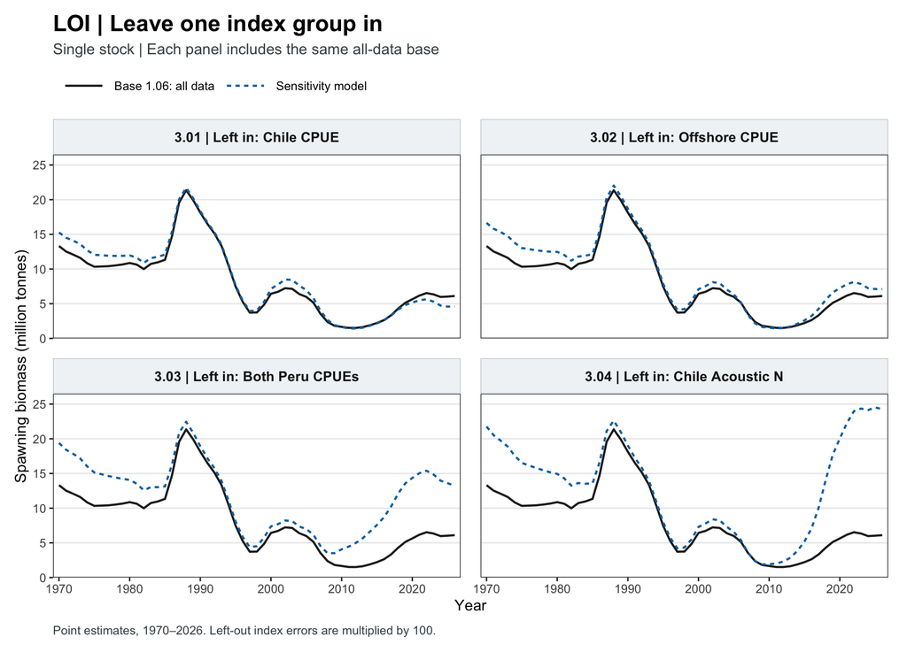

Figure 1: Single-stock LOI comparisons. Each panel shows Base 1.06 with one of models 3.01–3.04; panel labels identify the index group left in.

## 1.2 LOO — leave one out

The named recent index group is downweighted; the other groups retain their base weights.

The largest LOO response occurred when Chile CPUE was left out (model 3.05): estimated 2026 spawning biomass increased to 11.80 million tonnes, 93% above the base. Leaving out North Chile acoustics (3.08) had the opposite effect, reducing the estimate to 4.31 million tonnes (30% below the base) and producing a declining trajectory in the most recent years. Leaving out Offshore CPUE (3.06) or both Peru CPUE series (3.07) had smaller effects, with 2026 estimates of 6.60 and 6.73 million tonnes, respectively (8% and 10% above the base).

Taken together, the two analyses show that North Chile acoustics support higher recent biomass, while Chile CPUE restrains it within the fitted model. The high biomass in the Peru CPUE-only run does not translate into a large decrease when those indices are left out; their omission instead produces a modest increase. The effects therefore depend on which other indices remain in the model, and cannot be summarized as a uniformly positive or negative influence of every index across both analyses.

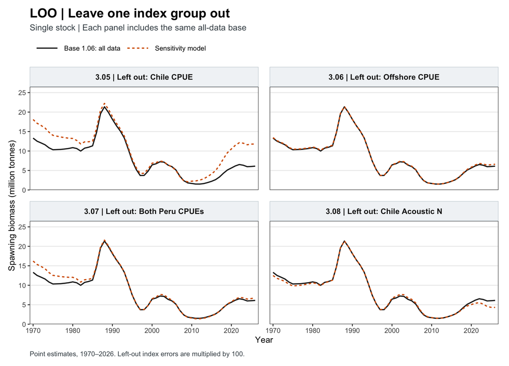

Figure 2: Single-stock LOO comparisons. Each panel shows Base 1.06 with one of models 3.05–3.08; panel labels identify the index group left out.

# 2 Additional model comparisons

| Model | Leaves In |
| --- | --- |
| 3.01 | Chile CPUE |
| 3.02 | Offshore CPUE |
| 3.03 | Both Peru CPUEs |
| 3.04 | Acoustic N Chile |

### 2.0.1 Single-stock hypothesis

#### 2.0.1.1 Biomass

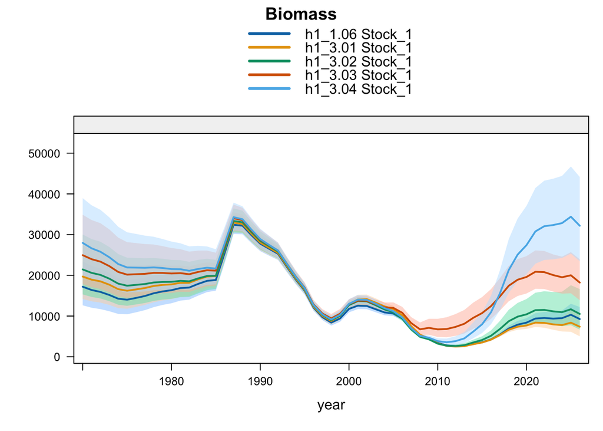

Plot comparing biomass estimates from leaving one index abundance in.

#### 2.0.1.2 Fit to Survey

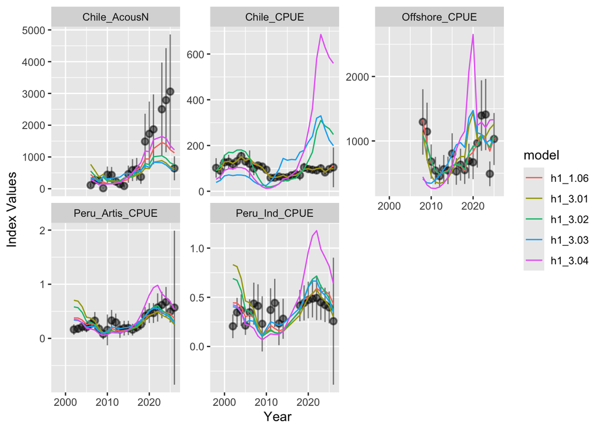

### 2.0.2 Two-stock hypothesis

#### 2.0.2.1 Biomass

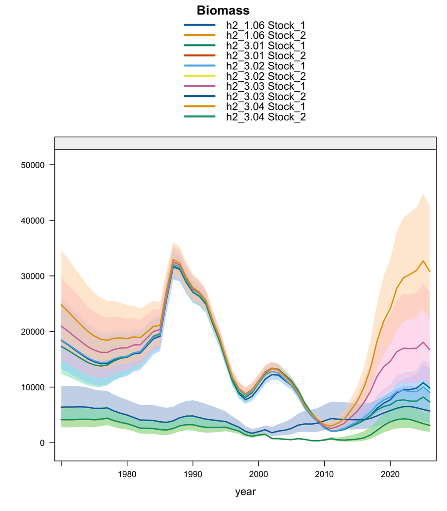

Plot comparing biomass estimates from leaving one index abundance in.

#### 2.0.2.2 Fit to Survey

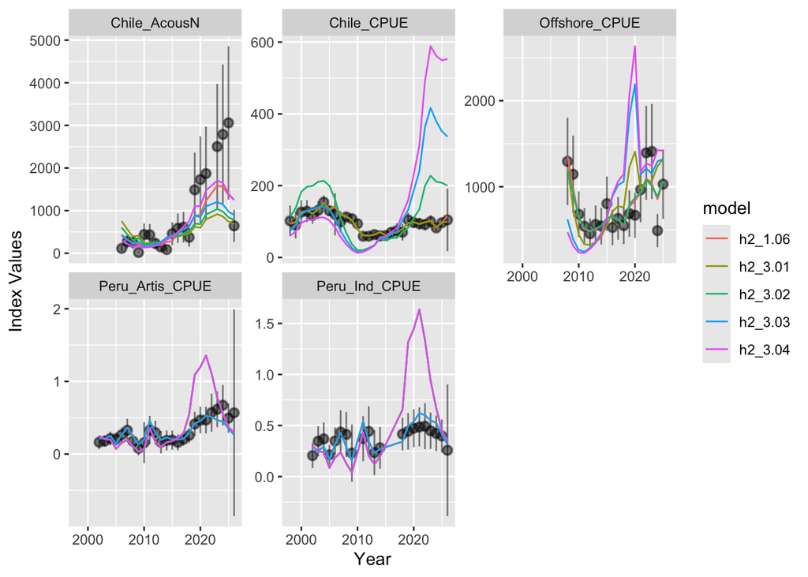

## 2.1 Leave-one-out Analysis

Only indices with recent data are considered: CPUE indices for Chile, Peru and offshore, and Chile Acoustic N. Age composition data were left in.

| Model | Leaves Out |
| --- | --- |
| 3.05 | Chile CPUE |
| 3.06 | Offshore CPUE |
| 3.07 | Both Peru CPUEs |
| 3.08 | Acoustic N Chile |

### 2.1.1 Single-stock hypothesis

#### 2.1.1.1 Biomass

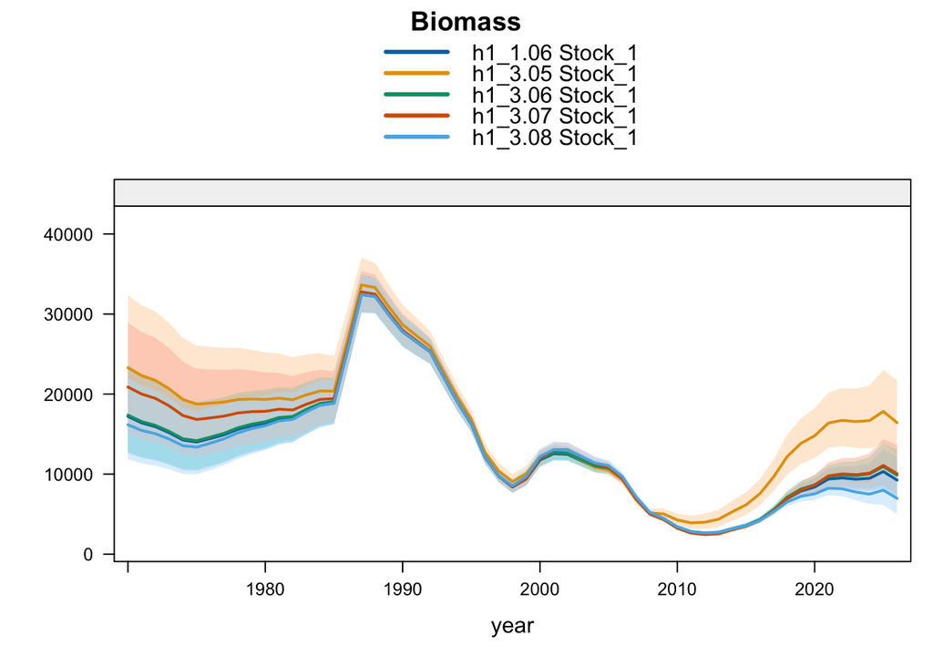

Plot comparing biomass estimates from leaving one index abundance out.

#### 2.1.1.2 Fit to Survey

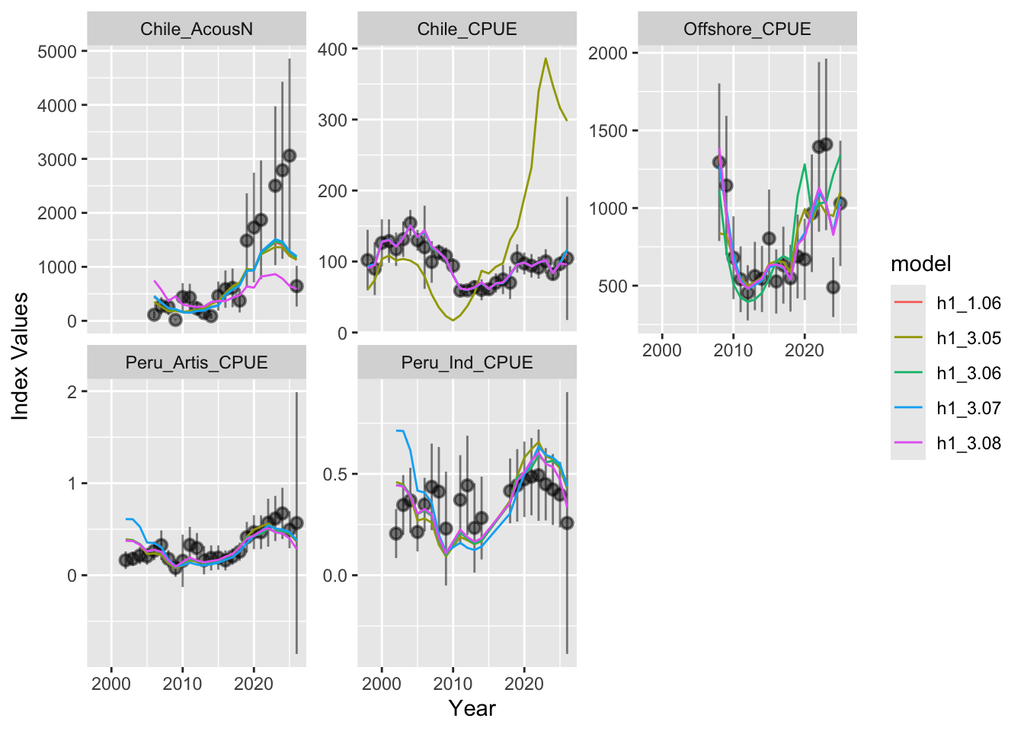

### 2.1.2 Two-stock hypothesis

#### 2.1.2.1 Biomass

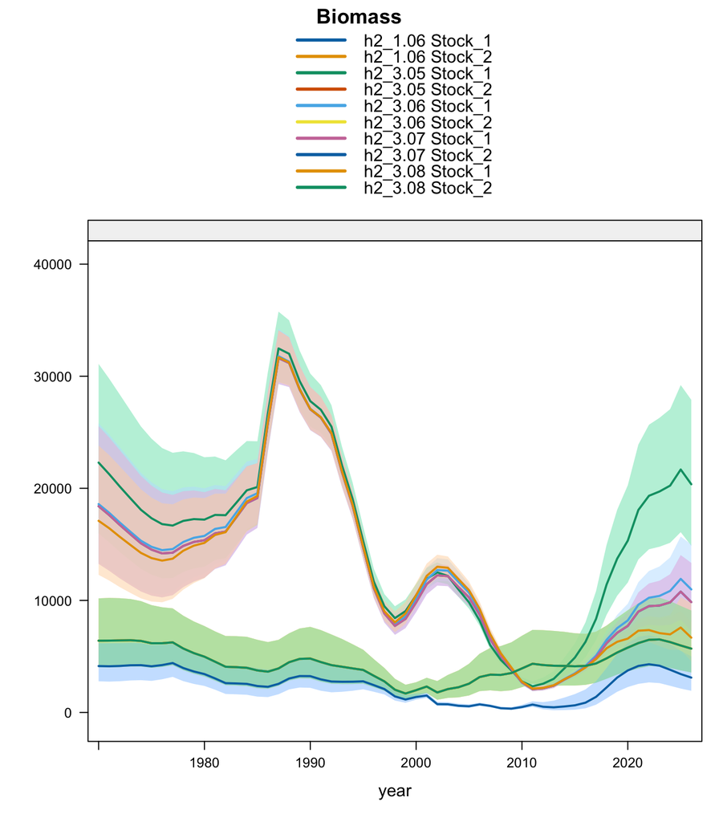

Plot comparing biomass estimates from leaving one index abundance out.

#### 2.1.2.2 Fit to Survey

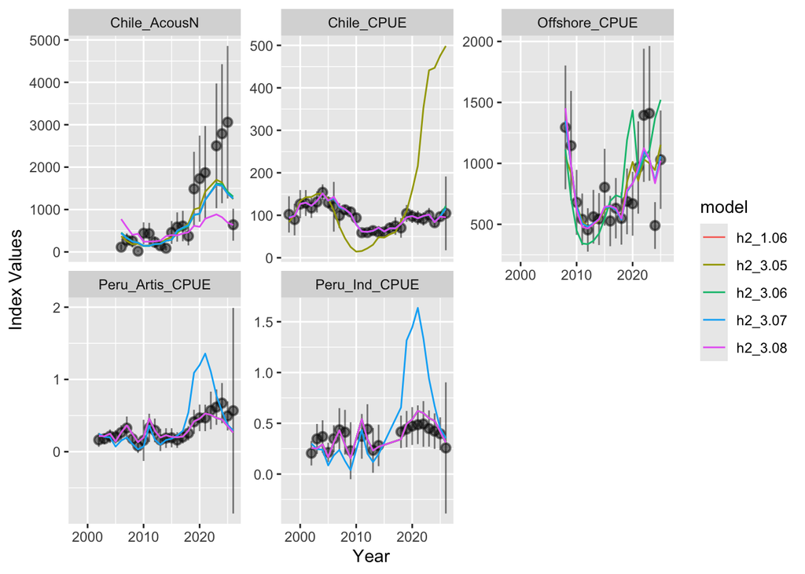